# Computers analysis

George Mount

# Does the presence of a CD-ROM affect sales price?

## Introduction

CD-ROMs seem to be the hot new thing, etc., etc….

Let’s call in all of our packages and get started:

```r
library(tidyverse)
library(readxl)
library(psych)
library(broom)
library(formattable)
```

## Data

The source of this data is the *Journal of Applied Econometrics*. It came to us in an Excel file:

```r
computers <- read_excel("../../datasets/computers.xlsx")
computers
```

| id | price | speed | hd | ram | screen | cd | multi | premium | ads | trend |
| --- | --- | --- | --- | --- | --- | --- | --- | --- | --- | --- |
| 1 | 1499 | 25 | 80 | 4 | 14 | no | no | yes | 94 | 1 |
| 2 | 1795 | 33 | 85 | 2 | 14 | no | no | yes | 94 | 1 |
| 3 | 1595 | 25 | 170 | 4 | 15 | no | no | yes | 94 | 1 |
| 4 | 1849 | 25 | 170 | 8 | 14 | no | no | no | 94 | 1 |
| 5 | 3295 | 33 | 340 | 16 | 14 | no | no | yes | 94 | 1 |
| 6 | 3695 | 66 | 340 | 16 | 14 | no | no | yes | 94 | 1 |
| 7 | 1720 | 25 | 170 | 4 | 14 | yes | no | yes | 94 | 1 |
| 8 | 1995 | 50 | 85 | 2 | 14 | no | no | yes | 94 | 1 |
| 9 | 2225 | 50 | 210 | 8 | 14 | no | no | yes | 94 | 1 |
| 10 | 2575 | 50 | 210 | 4 | 15 | no | no | yes | 94 | 1 |

[output cut: 990 more lines]

There are 6,259 rows and 11 columns in this dataset.

The descriptive statistics for `price` are as follows. The average price is $2,220

```r
describe(computers$price)
```

|  | vars | n | mean | sd | median | trimmed | mad | min | max | range | skew | kurtosis | se |
| --- | --- | --- | --- | --- | --- | --- | --- | --- | --- | --- | --- | --- | --- |
| X1 | 1 | 6259 | 2219.58 | 580.8 | 2144 | 2182.58 | 593.04 | 949 | 5399 | 4450 | 0.71 | 0.73 | 7.34 |

## Methods

We will conduct an independent samples t-test at the 95% confidence level.

Our hypothesis: **there is no difference in sales price of computers with and without a CD-ROM**.

First we’ll visually inspect the distribution of price by CD to confirm the CLT is likely to apply. If that looks good, we will conduct a two-tail t-test at the 95% confidence level.

## Results

### Descriptive statistics

```r
group_summary <- computers %>%
  group_by(cd) %>%
  summarise(count_records = n(), avg_price = mean(price))
group_summary
```

| cd | count_records | avg_price |
| --- | --- | --- |
| no | 3351 | 2112.812 |
| yes | 2908 | 2342.606 |

There are 3351 computers without a CD and 2908 with.

### Visualization

It looks good:

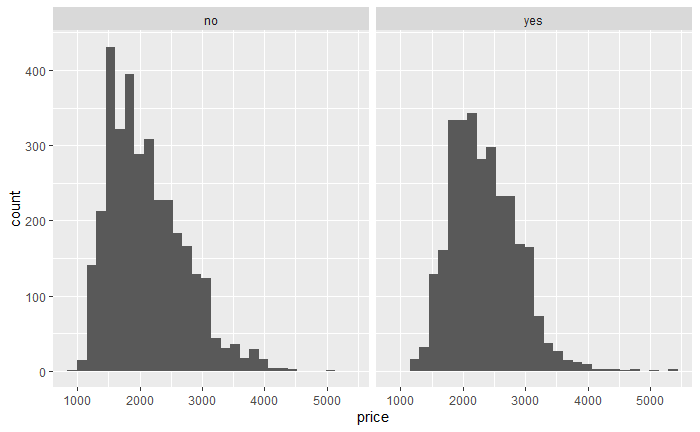

```r
ggplot(data = computers, aes(x = price)) +
  geom_histogram() +
  facet_grid(~ cd)
```

### T-test

The full results are as follows:

```r
cd_test <- t.test(price ~ cd, data = computers)
tidy_cd_test <- tidy(cd_test)
tidy_cd_test
```

| estimate | estimate1 | estimate2 | statistic | p.value | parameter | conf.low | conf.high | method | alternative |
| --- | --- | --- | --- | --- | --- | --- | --- | --- | --- |
| -229.7936 | 2112.812 | 2342.606 | -16.07486 | 5.242466e-57 | 6256.683 | -257.8171 | -201.7701 | Welch Two Sample t-test | two.sided |

## Conclusion

CD-ROMs seem to be the hot new thing. Are there other things influencing it?

Maybe premium computers tend to have CD Roms, and *that’s* what is really affecting the price. I would want to test this. We’d also want to evaluate the overall cost/benefit of including this feature.

## Appendix

- [Link to original dataset](https://rdrr.io/cran/Ecdat/man/Computers.html)
- A computer of a CD-ROM drive :)

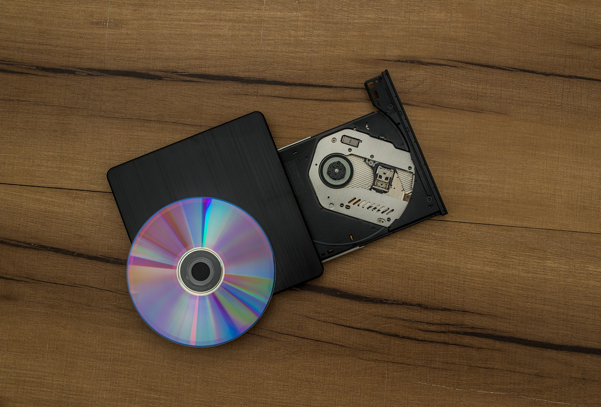

CD drive